# Análisis Geoespacial para la Conservación

BID-2408 | Enero - Julio 2026

[figure not shown]

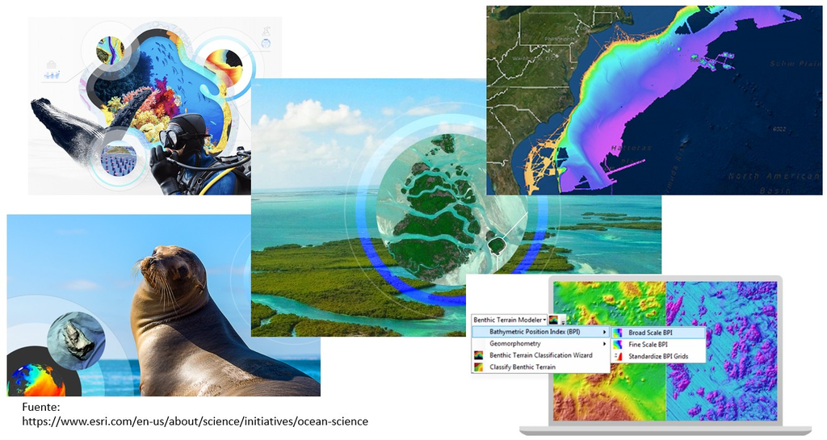

> Todas las cosas están relacionadas entre sí, pero las cosas más próximas en el espacio tienen una relación mayor que las distantes -Waldo Tobler.

# Bienvenida

Esta asignatura ofrece formación teórica y práctica en SIG y Percepción Remota para la conservación de ecosistemas marinos y costeros. Aprenderás a procesar datos georreferenciados y a seleccionar la información adecuada para tus investigaciones, comunicando resultados con rigor científico y visión espacio-temporal. El curso te capacitará para proponer soluciones a problemas ambientales complejos mediante el uso de herramientas clave como QGIS, R y Google Earth Engine.

## Temario de la asignatura

[figure not shown]

## Competencias específicas

- Domina las bases de SIG y PR, evaluando plataformas, atributos y fuentes de datos idóneos para la investigación.
- Genera datos geográficos y aplica proyecciones y principios de diseño para elaborar mapas de estudio y resultados.
- Ejecuta procesos vectoriales y ráster, incluyendo álgebra de mapas, cálculos en la nube y programación básica en R.
- Identifica productos satelitales para costas y océanos, seleccionando los adecuados para analizar patrones en series de tiempo.
- Emplea datos espaciales para modelos de distribución de especies y el estudio del cambio climático en la conservación.

## Competencias genéricas

- Habilidades en el uso de las tecnologías de la información y de la comunicación.
- Capacidad de trabajo en equipo.
- Capacidad de abstracción, análisis y síntesis.
- Habilidades para buscar, procesar y analizar información procedente de literatura especializada.
- Capacidad para identificar, plantear y resolver problemas.
- Habilidad para trabajar en forma autónoma.
- Capacidad de aplicar los conocimientos en la práctica.

## Horario

- Martes 10 a 13 horas
- Miércoles 12 a 14 horas

## Examen diagnóstico

[figure not shown]

## Rúbricas

[figure not shown]

# Unidades

## Introducción al Pensamiento Geoespacial

La primera unidad, comprende las bases de los SIG y PR. Reconoce las ventajas y desventajas de estas tecnologías y evalúa qué plataformas y atributos de los datos geográficos son los apropiados para la investigación. Identifica las fuentes de datos geográficos.

### Temas

- Introducción y evolución de los Sistemas de Información Geográfica.
- Introducción y evolución de la percepción remota (PR).
- Aplicaciones, ventajas y desventajas de los SIG y la PR.
- Estructuras de datos: vectoriales y raster.
- Fuentes de datos.

### Diapositivas de la unidad

### Actividades de la unidad

| Actividad | Descripción | Entrega | Cargue aquí |
| --- | --- | --- | --- |
| Glosario de conceptos | Investiga los conceptos de SIG, percepción remota, radiación electromagnética, longitud de onda, espectro electromagnético, ventanas atmosféricas. | 03-feb-2026 |  |
| Cuadro comparativo resoluciones | Realiza búsqueda en páginas de agencias espaciales para conocer las 4 resoluciones de 3 satélites. | 03-feb-2026 |  |
| [Práctica satélites](https://drjpg.github.io/GEOESPACIAL-SATELITES/) | Práctica en Google Earth Engine para explorar 3 satélites multiespectrales con distintas resoluciones. | 09-feb-2026 |  |

### Instrumento de evaluación

¡Bien hecho  
vas muy bien!

## Bases de Cartografía

La unidad “Bases de Cartografía” cubre los fundamentos para representar información geográfica. Incluye sistemas de coordenadas y proyecciones, generación de datos (digitalización, GPS, polígonos, geocodificación), escalas cartográficas y diseño de mapas efectivos mediante formas, colores y jerarquías. También aborda la creación de mapas con elementos clave como flecha norte, leyenda, escala, cuadrícula y mapas de contexto.

### Temas

- Sistemas de coordenadas y proyecciones.
- Generación de datos geográficos: Digitalización, Puntos GPS, Polígonos, Geocodificación.
- Escalas cartográficas.
- Diseño y comunicación efectiva a través de mapas: Formas, Rampas de color, Jerarquía
- Diseño de mapas de área de estudio y de resultados
- Elementos esenciales: Flecha norte, Leyenda, Barra escala, Cuadrícula, Marco, Coordenadas, Descripción, Mapa contexto.

### Diapositivas de la unidad

### Actividades de la unidad

| Actividad | Descripción | Entrega | Cargue aquí |
| --- | --- | --- | --- |
| [Práctica proyecciones](https://drjpg.github.io/GEOESPACIAL-PROYECCIONES/) | Mapeo y cálculo de áreas para México y Marismas Nacionales en distintas proyecciones cartográficas. | 17-feb-2026 |  |
| [Mapa de área de estudio](https://drjpg.github.io/AREA-ESTUDIO/) | Elaborar un mapa de área de estudio utilizando el software QGIS, integrando datos vectoriales, raster y tabulares para generar mapas temáticos claros y estéticamente adecuados. | 06-mar-2026 |  |
| [Mapa de área de estudio con R](https://drjpg.github.io/AREA-ESTUDIO-R/) | Elaborar un mapa de área de estudio claro, estéticamente adecuado y con calidad de publicación científica utilizando el lenguaje de programación R. | 12-mar-2026 |  |

### Instrumento de evaluación

¡Muy bien  
sigue esforzándote!

## Análisis Geoespacial

La tercera unidad abordará técnicas de análisis exploratorio de datos geográficos y geoprocesamientos básicos en datos vectoriales y raster. Se estudiarán operaciones como recortar, extraer, disolver, unir, intersección y áreas de influencia en vectoriales, y operaciones locales, focales, globales y zonales en raster. Además, se introducirá el uso de Google Earth Engine y el lenguaje R para análisis geoespacial.

### Temas

- Análisis exploratorio de datos geográficos.
- Geoprocesamientos básicos.
- Operaciones con datos vectoriales.
- Operaciones con datos raster.
- Procesamiento en la nube: Google Earth Engine.
- Introducción a R para el análisis geoespacial.

### Diapositivas de la unidad

### Actividades de la unidad

[output not shown]

### Instrumento de evaluación

¡Lo estás  
haciendo bien!

## Productos satelitales para costas y océanos

La cuarta unidad se centrará en los productos satelitales para el estudio de costas y océanos. Se examinarán índices espectrales y variables biofísicas clave para analizar la tierra y las costas, así como la cobertura y uso del suelo. En el ámbito marino, se estudiarán datos satelitales sobre el color del océano, clorofila, temperatura superficial y salinidad. También se analizarán series temporales para identificar cambios y tendencias en estas variables.

### Temas

- Tierra y costas.
- Índices espectrales.
- Variables biofísicas.
- Cobertura y uso de suelo.
- Productos satelitales del océano.
- Color del océano.
- Concentración de clorofila.
- Temperatura superficial.
- Salinidad.
- Series de tiempo.

### Diapositivas de la unidad

### Actividades de la unidad

[output not shown]

### Instrumento de evaluación

¡Vamos  
ya casi!

## Aplicaciones del análisis geoespacial para la conservación

La quinta unidad abordará el uso del análisis geoespacial en la conservación, incluyendo el mapeo y monitoreo de hábitats y especies, el modelado de distribución, la importancia de los corredores ecológicos, el rastreo de movimientos y migraciones, y el análisis de los efectos del cambio climático en los ecosistemas.

### Temas

- Mapeo de hábitat y monitoreo
- Modelado de distribución de especies
- Corredores ecológicos
- Rastreo de individuos
- Cambio climático

### Diapositivas de la unidad

### Actividades de la unidad

| Actividad | Descripción | Entrega | Cargue aquí |
| --- | --- | --- | --- |
| [Corredor biológico del jaguar](https://drjpg.github.io/CORREDOR-JAGUAR/) | Emplear en análisis multicriterio con variables ambientales y ponderación de expertos para el diseño de corredores biológicos del jaguar en Bahía de Banderas y Compostela. | 02-jun-2026 |  |
| [Modelado de distribución](https://drjpg.github.io/MODELADO-SP/) | Conducir el modelado de la distribución potencial del venado cola blanca empleando ocurrencias georreferenciadas, conjunto de variables bioclimáticas y un algoritmo de aprendizaje automático. | 02-jun-2026 |  |

### Instrumento de evaluación

¡Oye muy bien  
lo lograste!